# Triplett Replication

Sample Analysis on Simulated Data

Blinded

5th May 2022

# Overview

Below we outline our proposed design along with an accompanying analysis plan. We provide a sample analysis using simulated data.

# Design and Analysis Plan

The proposed study is a within subjects design. The core hypothesis is that the presence of another person completing the same task, will lead to improved performance on that task. Each participant will complete the task four times, twice alone, and twice in the presence of another participant.

## Planned Analysis

### Presence/Competition Effects

To test this we will conduct a mixed effects model with presence included as a fixed effect and participant and presence included as random effects.

```
model1 <- lmerTest::lmer(time ~
                           condition
                         + (1+condition|ID), data=x)

summary(model1)
anova(model1)
```

### Order Effects

To test for order effects we blocked our trials by two groups as in the table.

| Trial | Group A | Group B |
| --- | --- | --- |
| 1 | Alone | Alone |
| 2 | Alone | Together |
| 3 | Together | Alone |
| 4 | Together | Together |

A second mixed effect model will include order as a fixed effect, that may interact with condition).

```
model2 <- lmerTest::lmer(time ~
                           order*condition
                         + (1+condition|ID), data=x)

anova(model1,model2)
anova(model2)
summary(model2)
```

### Covariates

```
model3 <- lmerTest::lmer(time ~
                           order*condition
                         + age
                         + gender
                         + (1+condition|ID), data=x)

anova(model1, model2, model3)
anova(model3)
summary(model3)
```

### Follow-up Analysis

#### Testing for ‘carry-over’ presence effects

The above models will provide a test of our hypotheses. However in order to interpret any effects, follow-up analyses will be required.

First we will isolate trials 2 and 3 and conduct a 2x2 mixed between-within ANOVA to test for an interaction between order and presence, across the two groups. The between subjects IV is group (A vs B) and the within subjects IV is condition (together vs alone).

```
rstatix::anova_test(
  data = x, dv = time, wid = ID,
  within = condition,
  between = group
)

#  ---------  #
# for pairwise comparisons

x$condition3 <- paste(x$condition, x$group)

aov1 <- aov(time ~ condition3,x)
summary(aov1)
TukeyHSD(aov1)
```

#### Interpreting Order Effects (between groups)

Because of differences in presence effects, any order effects may vary depending on group/block (A vs B). To test this we will conduct a 2x4 mixed between-within subjects ANOVA with group as the between subjects IV (group A vs group B), and trial number as the within subject IV (4 levels, Trial 1- Trial 4).

```
rstatix::anova_test(
  data = x, dv = time, wid = ID,
  within = order,
  between = group
)

x$condition3 <- paste(x$order, x$group)

aov1 <- aov(time ~ condition3,x)
summary(aov1)
TukeyHSD(aov1)
```

# Power

A-priori power analyses showed that to detect a small effect (*f* <sup>2</sup> = .02) a minimum sample of *N* 400 participants is required. Detecting a medium effect (*f* <sup>2</sup> = .15) requires a sample of *N* = 54, and detecting a large effect (*f* <sup>2</sup> = .35) requires a sample of *N* = 24. We aim to collect 400 participants.

## Small Effect

```
##
##      Multiple regression power calculation
##
##               u = 1
##               v = 399
##              f2 = 0.02
##       sig.level = 0.05
##           power = 0.8065292
```

## Medium Effect

```
##
##      Multiple regression power calculation
##
##               u = 1
##               v = 53
##              f2 = 0.15
##       sig.level = 0.05
##           power = 0.8050826
```

## Large Effect

```
##
##      Multiple regression power calculation
##
##               u = 1
##               v = 23
##              f2 = 0.35
##       sig.level = 0.05
##           power = 0.8085699
```

# Sample Analysis

Below we present a sample analysis described above using simulated data for *N* = 400.

## Hypothesis Testing

### Model 1 Condition

```
## Type III Analysis of Variance Table with Satterthwaite's method
##           Sum Sq Mean Sq NumDF  DenDF F value    Pr(>F)
## condition 686.75  686.75     1 866.26  60.477 2.111e-14 ***
## ---
## Signif. codes:  0 '***' 0.001 '**' 0.01 '*' 0.05 '.' 0.1 ' ' 1
```

```
## Linear mixed model fit by REML. t-tests use Satterthwaite's method [
## lmerModLmerTest]
## Formula: time ~ condition + (1 + condition | ID)
##    Data: x
##
## REML criterion at convergence: 8463.8
##
## Scaled residuals:
##     Min      1Q  Median      3Q     Max
## -3.7761 -0.6720 -0.0126  0.6766  3.5870
##
## Random effects:
##  Groups   Name              Variance Std.Dev. Corr
##  ID       (Intercept)        0.4601  0.6783
##           conditiontogether  0.2623  0.5122   -1.00
##  Residual                   11.3556  3.3698
## Number of obs: 1600, groups:  ID, 400
##
## Fixed effects:
##                   Estimate Std. Error       df t value Pr(>|t|)
## (Intercept)        38.9354     0.1239 420.0499 314.316  < 2e-16 ***
## conditiontogether  -1.3253     0.1704 866.2596  -7.777 2.11e-14 ***
## ---
## Signif. codes:  0 '***' 0.001 '**' 0.01 '*' 0.05 '.' 0.1 ' ' 1
##
## Correlation of Fixed Effects:
##             (Intr)
## condtntgthr -0.714
## optimizer (nloptwrap) convergence code: 0 (OK)
## boundary (singular) fit: see help('isSingular')
```

### Model 2 Condition with Order as Interaction term

```
## refitting model(s) with ML (instead of REML)
```

```
## Data: x
## Models:
## model1: time ~ condition + (1 + condition | ID)
## model2: time ~ order * condition + (1 + condition | ID)
##        npar    AIC    BIC  logLik deviance  Chisq Df Pr(>Chisq)
## model1    6 8471.1 8503.4 -4229.5   8459.1
## model2   10 8443.9 8497.7 -4212.0   8423.9 35.169  4  4.289e-07 ***
## ---
## Signif. codes:  0 '***' 0.001 '**' 0.01 '*' 0.05 '.' 0.1 ' ' 1
```

```
## Missing cells for: order4:conditionalone, order1:conditiontogether.
## Interpret type III hypotheses with care.
```

```
## Type III Analysis of Variance Table with Satterthwaite's method
##                 Sum Sq Mean Sq NumDF  DenDF F value    Pr(>F)
## order           387.03 129.009     3 1197.6 11.6790 1.517e-07 ***
## condition        74.49  74.488     1 1195.8  6.7433  0.009525 **
## order:condition   7.43   7.429     1 1239.0  0.6726  0.412320
## ---
## Signif. codes:  0 '***' 0.001 '**' 0.01 '*' 0.05 '.' 0.1 ' ' 1
```

```
## Linear mixed model fit by REML. t-tests use Satterthwaite's method [
## lmerModLmerTest]
## Formula: time ~ order * condition + (1 + condition | ID)
##    Data: x
##
## REML criterion at convergence: 8431.5
##
## Scaled residuals:
##     Min      1Q  Median      3Q     Max
## -3.9242 -0.6752 -0.0010  0.6732  3.4115
##
## Random effects:
##  Groups   Name              Variance Std.Dev. Corr
##  ID       (Intercept)        0.6276  0.7922
##           conditiontogether  0.3350  0.5788   -1.00
##  Residual                   11.0462  3.3236
## Number of obs: 1600, groups:  ID, 400
##
## Fixed effects:
##                           Estimate Std. Error        df t value Pr(>|t|)
## (Intercept)                39.5453     0.1708 1136.2495 231.483  < 2e-16 ***
## order2                     -0.8003     0.2904 1503.5824  -2.756  0.00593 **
## order3                     -1.6394     0.2904 1503.5824  -5.646 1.97e-08 ***
## order4                     -1.6178     0.4100 1432.9864  -3.946 8.33e-05 ***
## conditiontogether          -0.4180     0.3372 1593.6604  -1.240  0.21521
## order2:conditiontogether   -0.3937     0.4801 1238.9754  -0.820  0.41232
## ---
## Signif. codes:  0 '***' 0.001 '**' 0.01 '*' 0.05 '.' 0.1 ' ' 1
##
## Correlation of Fixed Effects:
##             (Intr) order2 order3 order4 cndtnt
## order2      -0.557
## order3      -0.557  0.310
## order4      -0.394  0.216  0.712
## condtntgthr -0.020  0.019 -0.583 -0.816
## ordr2:cndtn  0.000 -0.423  0.423  0.585 -0.712
## fit warnings:
## fixed-effect model matrix is rank deficient so dropping 2 columns / coefficients
## optimizer (nloptwrap) convergence code: 0 (OK)
## boundary (singular) fit: see help('isSingular')
```

### Model 3 Covariates Added

```
## refitting model(s) with ML (instead of REML)
```

[output not shown]

```
## Missing cells for: order4:conditionalone, order1:conditiontogether, order4:conditionalone:age, order1:conditiontogether:age.
## Interpret type III hypotheses with care.
```

[output not shown]

[output not shown]

```
##
## Correlation matrix not shown by default, as p = 13 > 12.
## Use print(x, correlation=TRUE)  or
##     vcov(x)        if you need it
```

```
## fit warnings:
## fixed-effect model matrix is rank deficient so dropping 4 columns / coefficients
## optimizer (nloptwrap) convergence code: 0 (OK)
## boundary (singular) fit: see help('isSingular')
```

# Follow-up Analyses

## Isolate Trials 2 and 3

### Test for ‘carry-over’ presence effects

#### Basic Descriptive Statistics

```
## $alone
##       mean       sd      min      max len
## 1 38.32546 3.469626 27.62921 49.48423 400
##
## $together
##       mean       sd      min      max len
## 1 37.71057 3.176291 29.04986 47.75986 400
```

```
## $a
##       mean       sd      min      max len
## 1 38.10608 3.624512 27.62921 49.48423 400
##
## $b
##       mean       sd      min      max len
## 1 37.92995 3.027212 30.45455 47.75986 400
```

#### Testing for differences

```
## ANOVA Table (type II tests)
##
##            Effect DFn DFd     F     p p<.05      ges
## 1           group   1 398 0.537 0.464       0.000709
## 2       condition   1 398 7.266 0.007     * 0.009000
## 3 group:condition   1 398 7.636 0.006     * 0.009000
```

#### Post-hoc Contrast

```
##              Df Sum Sq Mean Sq F value  Pr(>F)
## condition3    3    161   53.77   4.895 0.00223 **
## Residuals   796   8743   10.98
## ---
## Signif. codes:  0 '***' 0.001 '**' 0.01 '*' 0.05 '.' 0.1 ' ' 1
```

```
##   Tukey multiple comparisons of means
##     95% family-wise confidence level
##
## Fit: aov(formula = time ~ condition3, data = x)
##
## $condition3
##                              diff        lwr         upr     p adj
## alone b-alone a       -0.80650202 -1.6597240  0.04671995 0.0717168
## together a-alone a    -1.24525900 -2.0984810 -0.39203702 0.0010556
## together b-alone a    -0.79101698 -1.6442390  0.06220499 0.0804293
## together a-alone b    -0.43875697 -1.2919789  0.41446500 0.5479249
## together b-alone b     0.01548504 -0.8377369  0.86870702 0.9999634
## together b-together a  0.45424202 -0.3989800  1.30746399 0.5182233
```

```
## $`alone a`
##       mean       sd      min      max len
## 1 38.72871 3.809463 27.62921 49.48423 200
##
## $`alone b`
##       mean       sd      min      max len
## 1 37.92221 3.049301 30.45455 46.11473 200
##
## $`together a`
##       mean       sd      min      max len
## 1 37.48345 3.323995 29.04986 46.35874 200
##
## $`together b`
##       mean       sd     min      max len
## 1 37.93769 3.012592 30.6933 47.75986 200
```

#### Plotting the Responses

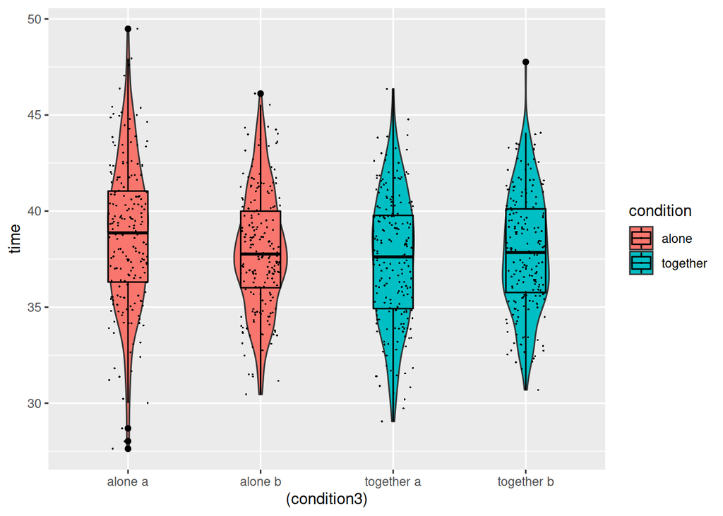

### Test for Order Effects (depending on group)

#### Basic Descriptive Statistics

```
## $`1`
##       mean       sd      min      max len
## 1 39.54528 3.461822 25.45597 51.47268 400
##
## $`2`
##      mean       sd      min      max len
## 1 38.3332 3.452698 27.62921 49.48423 400
##
## $`3`
##       mean       sd      min      max len
## 1 37.70283 3.193171 29.04986 46.35874 400
##
## $`4`
##       mean      sd      min      max len
## 1 37.50948 3.40251 27.97962 46.62233 400
```

```
## $a
##       mean       sd      min      max len
## 1 38.18801 3.529074 25.45597 51.47268 800
##
## $b
##       mean       sd      min      max len
## 1 38.35739 3.407174 27.97962 47.76231 800
```

#### Testing for differences

```
## ANOVA Table (type II tests)
##
## $ANOVA
##        Effect DFn  DFd      F        p p<.05      ges
## 1       group   1  398  0.971 3.25e-01       0.000634
## 2       order   3 1194 30.094 9.33e-19     * 0.053000
## 3 group:order   3 1194  3.690 1.20e-02     * 0.007000
##
## $`Mauchly's Test for Sphericity`
##        Effect     W     p p<.05
## 1       order 0.992 0.646
## 2 group:order 0.992 0.646
##
## $`Sphericity Corrections`
##        Effect   GGe        DF[GG]    p[GG] p[GG]<.05   HFe        DF[HF]
## 1       order 0.995 2.98, 1187.53 1.14e-18         * 1.003 3.01, 1197.49
## 2 group:order 0.995 2.98, 1187.53 1.20e-02         * 1.003 3.01, 1197.49
##      p[HF] p[HF]<.05
## 1 9.33e-19         *
## 2 1.20e-02         *
```

#### Contrasts

```
##               Df Sum Sq Mean Sq F value Pr(>F)
## condition3     7   1148  163.96   14.43 <2e-16 ***
## Residuals   1592  18090   11.36
## ---
## Signif. codes:  0 '***' 0.001 '**' 0.01 '*' 0.05 '.' 0.1 ' ' 1
```

```
##   Tukey multiple comparisons of means
##     95% family-wise confidence level
##
## Fit: aov(formula = time ~ condition3, data = x)
##
## $condition3
##                diff        lwr         upr     p adj
## 1 b-1 a  0.45450915 -0.5685481  1.47756641 0.8800396
## 2 a-1 a -0.58931561 -1.6123729  0.43374164 0.6553403
## 2 b-1 a -1.38033259 -2.4033898 -0.35727534 0.0011513
## 3 a-1 a -1.83457461 -2.8576319 -0.81151735 0.0000017
## 3 b-1 a -1.39581763 -2.4188749 -0.37276038 0.0009500
## 4 a-1 a -2.09618186 -3.1192391 -1.07312461 0.0000000
## 4 b-1 a -1.52091019 -2.5439674 -0.49785294 0.0001855
## 2 a-1 b -1.04382476 -2.0668820 -0.02076751 0.0416745
```

[output cut: 20 more lines]

```
## $`1 a`
##       mean       sd      min      max len
## 1 39.31803 3.529651 25.45597 51.47268 200
##
## $`1 b`
##       mean       sd      min      max len
## 1 39.77254 3.386208 31.99555 47.76231 200
##
## $`2 a`
##       mean       sd      min      max len
## 1 38.72871 3.809463 27.62921 49.48423 200
##
## $`2 b`
##       mean       sd     min      max len
## 1 37.93769 3.012592 30.6933 47.75986 200
##
## $`3 a`
##       mean       sd      min      max len
## 1 37.48345 3.323995 29.04986 46.35874 200
##
## $`3 b`
##       mean       sd      min      max len
## 1 37.92221 3.049301 30.45455 46.11473 200
##
## $`4 a`
##       mean       sd      min      max len
## 1 37.22184 2.995259 28.92987 45.48607 200
##
## $`4 b`
##       mean       sd      min      max len
## 1 37.79712 3.751593 27.97962 46.62233 200
```

#### Plotting the Responses

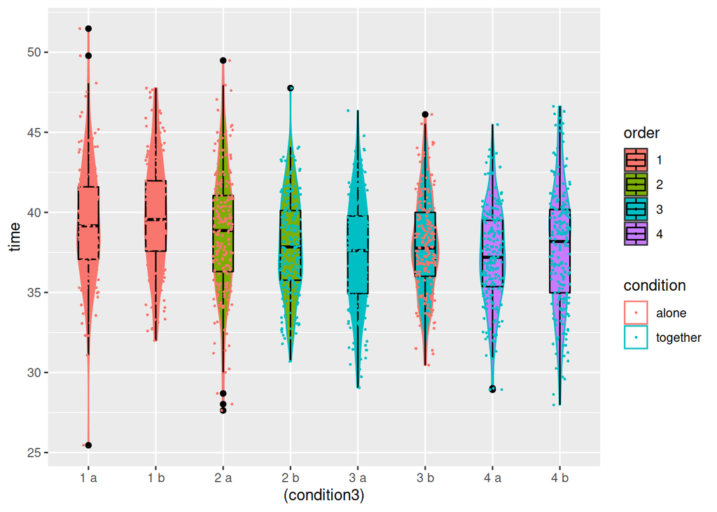